# Day6

Pyhton 数据分析之展示 1

## Matplotlib 基础

matplotlib 是一个 Python 的 2D 图形包。 pyplot 封装了很多画图的函数

常以 plt 作为其简写

```python
import matplotlib.pyplot as plt
import numpy as np
import pandas as pd
```

## plt.show() 函数

默认情况下， matplotlib.pyplot 不会直接显示图像，只有调用 plt.show() 时才会显示

plt.show() 默认在新窗口打开一副图像，并提供对图像进行操作的按钮

在 ipython 命令中，可以将它插入 notebook 中，并且不需要调用 plt.show() 也可以显示：

- %matplotlib notebook
- %matplotlib inline

```python
%matplotlib inline
```

## plt.plot() 函数

可以用来绘制线型图

```
Text(0.5,0,'X')
```

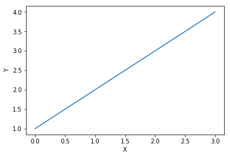

```python
plt.plot([1,2,3,4])
plt.ylabel('Y')
plt.xlabel('X') # 若要使用中文，需要其他参数进行设置
```

### 基本用法

指定 x 和 y

- plt.plot(x,y)

默认 x 为 0 到 n-1

- plt.plot(y)

因此，在上面的例子中，我们没有给定 x 的值，所以其默认值为 [0,1,2,3]

传入 x 和 y ：

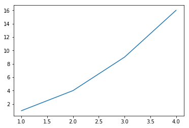

```python
plt.plot([1,2,3,4],[1,4,9,16])
```

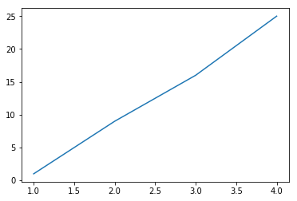

```python
plt.plot([1,2,3,4],[1,9,16,25])
plt.show()
```

### 字符参数

表示颜色的字符：

[figure not shown]

表示类型的字符：

[figure not shown]

以红色圆点显示：

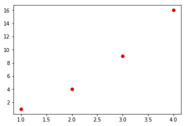

```python
plt.plot([1,2,3,4],[1,4,9,16],'ro')
```

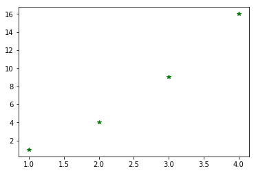

```python
plt.plot([1,2,3,4],[1,4,9,16],'g*')
plt.show()
```

### 显示范围

plt.axis([xmin,xmax,ymin,ymax])

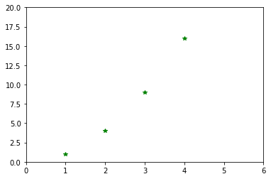

```python
plt.plot([1,2,3,4],[1,4,9,16],'g*')
plt.axis([0,6,0,20])
plt.show()
```

### 传入 NumPy 数组

事实上，传入的参数如果是列表，matplotlib 会在内部转为数组处理

在一个图里画多条线

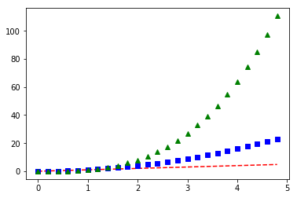

```python
t=np.arange(0.,5.,0.2)
plt.plot(t,t,'r--',
        t,t**2,'bs',
        t,t**3,'g^')
plt.show()
```

### 传入多组数据

事实上，上面的例子中不但向 plot 函数传入了数组，还传入了多组（x,y,format_str）参数，它们在同一张图上显示

这意味着我们不需要使用多个 plot 函数来画多组数组，只需要可以将这些组合放到一个 plot 函数中去即可

### 线条属性

之前提到，我们可以用字符串来控制线条的属性，事实上还可以通过关键词来改变线条的性质，例如 linewidth 可以改变线条的宽度， color 可以改变线条的颜色

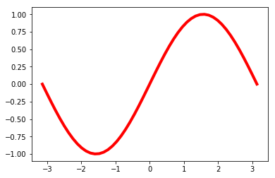

```python
x=np.linspace(-np.pi,np.pi)
y=np.sin(x)
plt.plot(x,y,linewidth=4.0,color='r')
plt.show()
```

#### 使用 plt.plot() 的返回值来设置线条属性

ploy 函数返回一个 Line2D 对象组成的列表，每个对象代表输入的一对组合，例如：

- line1,line2 为两个 Line2D 对象

line1,line2=lt.plot(x1,y1,x2,y2)

- 返回三个 Line2D 对象组成的列表

lines=plt.plot(x1,y1,x2,y2,x3,y3)

我们可以使用这个返回值来对线条属性进行设置：

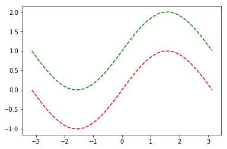

```python
plt.plot(x,y,'r--',x,y+1,'g--')
plt.show()
```

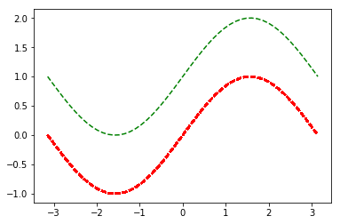

```python
line1,line2=plt.plot(x,y,'r--',x,y+1,'g--')
line1.set_antialiased(False)
plt.show()
```

#### plt.setp() 修改线条性质

更方便的做法是使用 plt 的 setp 函数：

```
[None, None]
```

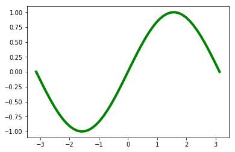

```python
line=plt.plot(x,y)
plt.setp(line,color='g',linewidth=4)
```

```
[None, None]
```

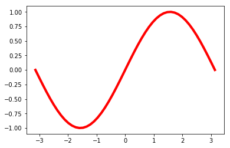

```python
line=plt.plot(x,y)
plt.setp(line,'color','r','linewidth','4')
```

### 子图

figure() 函数会产生一个指定编号为 num 的图：

- plt.figure(num)

使用 subplot 可以在一幅图中生成多个子图，参数为：

- plt.subplot(numrows,numcols,fignum)

当 numrows numcols < 10 时，中间的逗号可以省略，因此 plt.subplot(211) 相当于 plt.subplot(2,1,1)

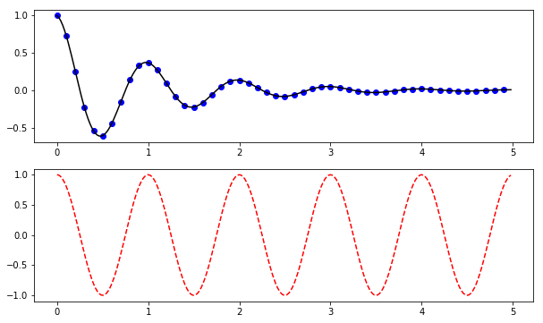

```python
def f(t):
    return np.exp(-t)*np.cos(2*np.pi*t)

t1=np.arange(0.0,5.0,0.1)
t2=np.arange(0.0,5.0,0.02)

plt.figure(figsize=(10,6))

plt.subplot(211)
plt.plot(t1,f(t1),'bo',t2,f(t2),'k')

plt.subplot(212)
plt.plot(t2,np.cos(2*np.pi*t2),'r--')

plt.show()
```

## 电影数据绘图

```python
# 去除警告提示
import warnings
warnings.filterwarnings('ignore')
```

```python
plt.rcParams['font.sans-serif']=['SimHei'] # 字体设置，可以解决中文显示
plt.rcParams['axes.unicode_minus']=False
```

```python
df=pd.read_excel('movie_data3.xlsx')
```

### 绘制每个国家或地区的电影数量的柱状图

柱状图（bar chart），是一种以长方形的长度为变量的表达图形的统计报告图，由一系列高度不等的纵向条纹表示数据分布的情况，用来比较两个或以上的价值（不同时间或者不同条件），只有一个变量，通常用于较小的数据分析。柱状图亦可横向排列，或用多维方式表达。

```python
data=df['产地'].value_counts()
data
```

```
美国      11979
日本       5052
中国大陆     3802
中国香港     2852
法国       2817
英国       2762
其他       1920
韩国       1351
德国       1032
意大利       749
加拿大       723
中国台湾      618
俄罗斯       477
西班牙       447
印度        357
澳大利亚      300
泰国        294
丹麦        198
瑞典        192
波兰        181
荷兰        155
比利时       139
墨西哥       119
阿根廷       116
巴西        101
Name: 产地, dtype: int64
```

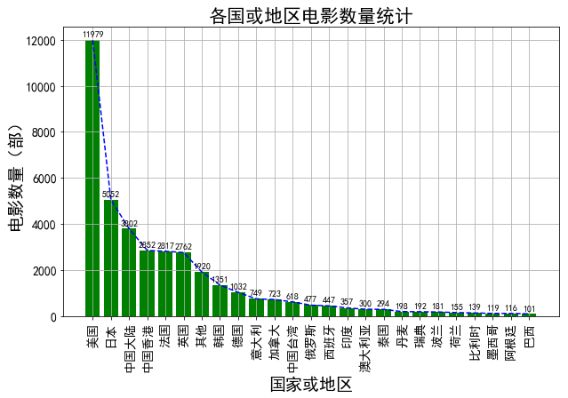

```python
x=data.index
y=data.values

plt.figure(figsize=(10,6))
plt.bar(x,y,color='g')
plt.title('各国或地区电影数量统计',fontsize=21)
plt.xlabel('国家或地区',fontsize=19)
plt.ylabel('电影数量（部）',fontsize=19)
plt.tick_params(labelsize=14)
plt.xticks(rotation=90)

for a,b in zip(x,y):
    plt.text(a,b+100,b,ha='center',va='bottom',fontsize=10)

plt.grid()
plt.plot(x,y,'b--')
plt.show()
```

### 绘制每年上映的电影数量的曲线图

曲线图又称折线图，是利用曲线的升降变化来表示被研究现象发展变化趋势的一种图形。它在分析研究社会经济现象的发展变化、依存关系等方面具有重要作用。

绘制曲线图时，如果是某一现象的时间指标，应将时间绘制在坐标轴的横轴上，指标绘制在坐标轴的纵轴上。如果是两个现象依存关系的显示，可以将表示原因的指标绘制在横轴上，表示结果的指标绘制在纵轴上。同时还应注意整个图形的长宽比例。

**1888-2015 年**

因为2016年的数据不完整，所以去除2016年的数据：

```python
data=df['年代'].value_counts()
data=data.sort_index()[:-2]
```

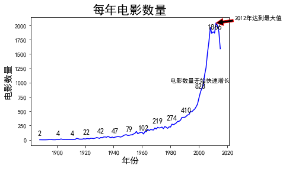

```python
x=data.index
y=data.values

plt.plot(x,y,'b')
plt.title('每年电影数量',fontsize=21)
plt.ylabel('电影数量',fontsize=15)
plt.xlabel('年份',fontsize=15)

for a,b in zip(x[::10],y[::10]):
    plt.text(a,b+50,b,ha='center',va='bottom',fontsize=12)

plt.annotate('2012年达到最大值',xy=(2012,data[2012]),xytext=(2025,2100),arrowprops=dict(facecolor='black',edgecolor='red'))
plt.text(1980,1000,'电影数量开始快速增长')
plt.show()
```

对于这幅图形，我们使用 xlabel，ylabel，title，text 方法设置了文字，其中：

- xlabel：x 轴标注
- ylabel：y 轴标注
- title：图形标题
- text：在指定位置放入文字

输入特殊符号支持使用 Tex 语法，用 $& 隔开。

除了使用 text 在指定位置标上文字之外，还可以使用 annotate 函数进行注释，annotate 主要有两个参数：

- xy：注释位置
- xytext：注释文字的位置

### 根据电影的长度绘制饼图

饼图英文学名为 Sector Graph，又名 Pie Graph，常用于统计学模块。2D 饼图为圆形。

仅排列在工作表的一列或一行中的数据可以绘制到饼图中。饼图显示一个数据系列（数据系列：在图表中绘制的相关数据点，这些数据源自数据表的行或列。图表中的每个数据系列具有唯一的颜色或图案，并且在图表的图例中表示。可以在图表中绘制一个或多个数据系列。饼图只有一个数据系列。）中各项的大小与各项总和的比例。饼图中的数据点（数据点：在图表中绘制的单个值。这些值由条形、柱形、折线、饼图或圆环图的扇面、圆点和其他被称为数据标记的图形表示。相同颜色的数据标记组成一个数据系列。）显示为整个饼图的百分比。

**函数原型** pie(x,explode=None,labels=None,colors=None,autopct=None,pctdistance=0.6,shadow=False,labeldistance1.1,startangle=None,radius=None)

**参数**

- x：（每一块）的比例，如果 sum(x) > 1 会使用 sum(x) 归一化
- labels：（每一块）饼图外侧显示的说明文字
- explode：（每一块）离开中心距离
- startangle：起始绘图角度，默认是从 x 轴正方向逆时针画起，如设定 =90 则从 y 轴正方向画起
- shadow：是否绘制阴影
- labeldistance：label 绘制位置，相对于半径的比例，如 < 1 则绘制在饼图内侧
- autopct：控制饼图内百分比设置，可以使用 format 字符串或者 format function
- %1.1f：指小数点前后位数（没有就用空格补齐）
- pctdistance：类似于 labeldistance ，指定 autopct 的位置刻度
- radius：控制饼图半径

**返回值**

- 如果没有设置 autopct 返回 (patches,texts)
- 如果设置 autopct，返回 (patches,texts,autotexts)

```python
data=pd.cut(df['时长'],[0,60,90,110,1000]).value_counts()
data
```

```
(90, 110]      13232
(0, 60]        10323
(60, 90]        7727
(110, 1000]     7451
Name: 时长, dtype: int64
```

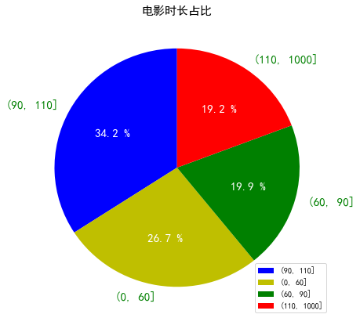

```python
y=data.values
y=y/sum(y) # 进行归一化处理

plt.figure(figsize=(7,7))
plt.title('电影时长占比',fontsize=15)
patches,l_text,p_text=plt.pie(y,labels=data.index,autopct='%.1f %%',colors='bygr',startangle=90)

for i in p_text:
    i.set_size(15)
    i.set_color('w')

for i in l_text:
    i.set_size(15)
    i.set_color('g')

plt.legend()
plt.show()
```

### 根据电影的评分绘制频率分布直方图

直方图（Histogram）又称质量分布图，是一种统计报告图，由一系列高度不等的纵向条纹或线段表示数据分布的情况。一般用横轴表示数据类型，纵轴表示分布情况。

直方图是数值数据的精确图形表示，这是一个连续变量（定量变量）的概率分布的估计，并且被卡尔皮尔逊（karl Pearson）首先引入，它是一种条形图。为了构建直方图，第一步是将值的范围分段，即将整个值的范围分成一系列间隔，然后计算每个间隔中有多少值。这些值通常被指定为连续的，不重叠的变量间隔。间隔必须相邻，并且通常是（但不是必须的）相等的大小。

直方图也可以被归一化以显示“相对”频率，然后，它显示了属于几个类别中的每个案例的比例，其高度等于1。

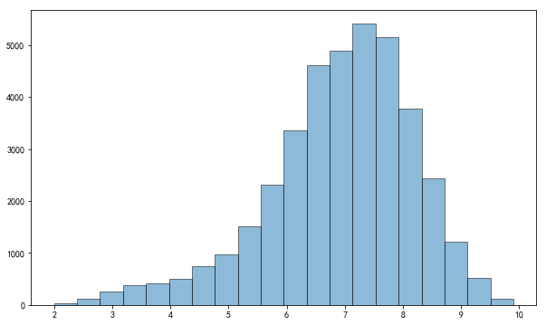

```python
plt.figure(figsize=(10,6))
plt.hist(df['评分'],bins=20,edgecolor='k',alpha=0.5)
plt.show()
```

- arr：需要计算直方图的一维数组
- bins：直方图的柱数，可选项，默认为 10
- normed：是否将得到的直方图向量归一化，默认为 0
- facecolor：直方图颜色
- edgecolor：直方图边框颜色
- alpha：透明度
- histtype：直方图类型，'bar','barstacked','step','stepfilled'

**返回值**

- n：直方图向量，是否归一化由参数 normed 设定
- bins：返回各个 bin 的区间范围
- patches：返回每个 bin 里面包含的数据，是一个 list